# Survey state plot reprex

Brian McGreal

2026-10-08

Here is how I’m coding my population-level plots of observed time series and underlying states along with their confidence intervals. First I pull in the MARSS model object ssm_coho, as well as two keys (keyX and keyY) which relate the model output to the proper underlying population ID.

```r
ssm_coho <- readRDS(file=here::here("ssm_coho_Afull.rds"))
keyX_coho <- read_excel(here("xtT_statekey.xlsx"), sheet = "coho")
keyY_coho <- read_excel(here("ytT_statekey.xlsx"), sheet = "coho")
load(file=here::here("nosa_cohoPOP.Rda"))
```

pop_list requires some cleaning so I do that ‘under the hood’ but here’s what it looks like. pop_names is just the names of each population and the popID for labelling plots.

```r
head(pop_list)
```

```
## # A tibble: 6 × 10
##   RECOVERYDOMAIN           PopID LOCATIONNAME ESAPOPNAME COMMONPOPNAME WATERBODY
##   <chr>                    <dbl> <chr>        <chr>      <chr>         <chr>
## 1 Willamette/Lower Columb…   292 Clackamas R… Salmon, c… Clackamas Ri… Clackama…
## 2 Willamette/Lower Columb…   304 Sandy River  Steelhead… Sandy River   Sandy Ri…
## 3 Willamette/Lower Columb…   315 Clackamas R… Steelhead… Clackamas Ri… Clackama…
## 4 Willamette/Lower Columb…   316 Calapooia R… Steelhead… Calapooia Ri… Calapooi…
## 5 Willamette/Lower Columb…   317 Molalla Riv… Steelhead… Molalla River Molalla …
## 6 Willamette/Lower Columb…   318 North Santi… Steelhead… North Santia… North Sa…
## # ℹ 4 more variables: CommonName <chr>, Run <chr>, `MPG/Stratum` <chr>,
## #   CommonPopName <chr>
```

```r
pop_names <- pop_list[-c(1, 3, 4, 6:10)]
head(pop_names)
```

```
## # A tibble: 6 × 2
##   PopID COMMONPOPNAME
##   <dbl> <chr>
## 1   292 Clackamas River
## 2   304 Sandy River
## 3   315 Clackamas River
## 4   316 Calapooia River
## 5   317 Molalla River
## 6   318 North Santiam River
```

Next I extract from the MARSS object state estimates and confidence intervals, as well as Y_t predictions and those intervals as well. **This is where I’m concerned I might not be grabbing the right information from the fitted model, specifically the “ytT” bit.** If this looks correct to you than these plots should be good.

```r
# pull fitted states from MARSS object
states_coho <- tsSmooth(ssm_coho, type = "xtT")

predobs_coho <- predict(ssm_coho, type = "ytT", interval = "prediction", level = 0.95)
obs_coho <- predobs_coho$pred
```

Now I’ve got to match the state key to the states in states_coho to assign each the proper popID.

```r
names(states_coho)[names(states_coho) == ".rownames"] <- "state"
states_coho$state <- as.numeric(sub("^X", "", states_coho$state))
states_coho <- states_coho %>%
  left_join(keyX_coho, by = c("state" = "State")) %>%
  select(-state)
states_coho$Year <- states_coho$t + 1979
states_coho <- rename(states_coho, Value = .estimate, SE = .se)
states_coho <- states_coho[-c(1)]
states_coho$Dataset <- "fitted"

states_coho$upper95 <- states_coho$Value + (states_coho$SE * 1.96)
states_coho$lower95 <- states_coho$Value - (states_coho$SE * 1.96)

states_coho <- states_coho %>%
  mutate(PopID = as.character(PopID)) %>%
  left_join(
    pop_names %>% mutate(PopID = as.character(PopID)),
    by = "PopID"
  )
```

Again here I match the state key to the rows in obs_coho, which are enumerated at the level of pop/method, since they make up the input data for the MARSS models. This match assigns each row to the proper popID.

```r
names(obs_coho)[names(obs_coho) == ".rownames"] <- "popmethod"
obs_coho$popmethod <- as.numeric(sub("^Y", "", obs_coho$popmethod))
obs_coho <- obs_coho %>%
  left_join(keyY_coho, by = c("popmethod" = "Popmethod")) %>%
  select(-popmethod)
obs_coho  <- obs_coho  %>%
  filter(!is.na(y))
obs_coho$Year <- obs_coho$t + 1979
obs_coho <- rename(obs_coho, Value = y, SE = se, upper95 = `Hi 95`, lower95 = `Lo 95`)
obs_coho$Dataset <- "observed"
obs_coho <- obs_coho %>%
  mutate(PopID = as.character(PopID)) %>%
  left_join(
    pop_names %>% mutate(PopID = as.character(PopID)),
    by = "PopID"
  )
obs_coho <- obs_coho[-c(1, 3)]
```

Next I bind these two datasets together (observations and underlying states). A step here drops all fitted state estimates from before or after the first and last observed year.

```r
# row bind
plotdata_coho <- rbind(states_coho, obs_coho)

# drop estimates from before any observations were made
plotdata_coho <- plotdata_coho %>%
  group_by(PopID) %>%
  filter(
    trimws(Dataset) == "observed" |
      (trimws(Dataset) == "fitted" & Year >= min(Year[trimws(Dataset) == "observed" & !is.na(Value)], na.rm = TRUE) &
         Year <= max(Year[trimws(Dataset) == "observed" & !is.na(Value)], na.rm = TRUE))) %>%
  ungroup()
```

Now that I have a dataset with both observations and fitted state estiamtes, I make my plot, including confidence intervals around each.

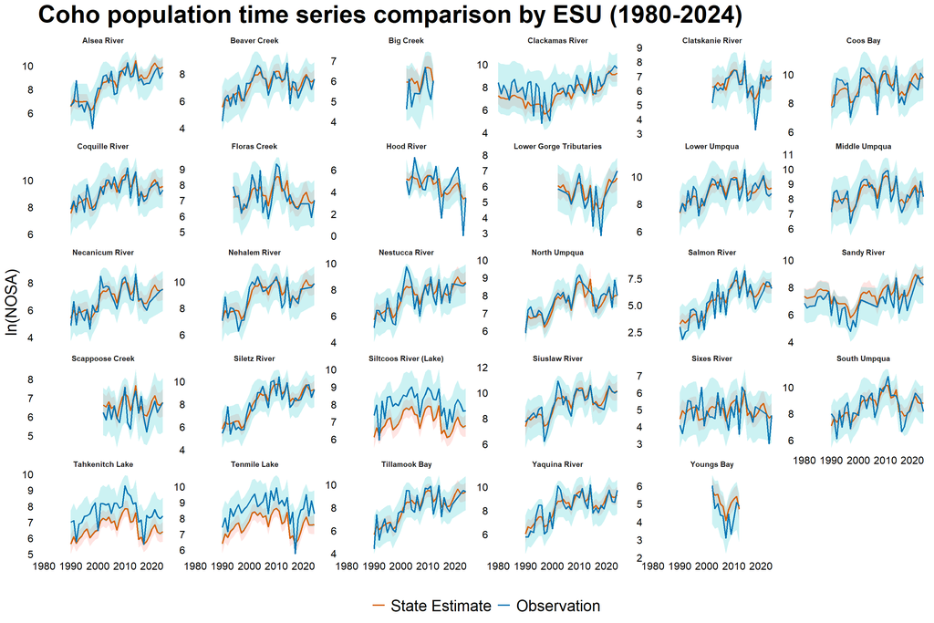

```r
statecompare_cohoOBVAR <- ggplot(plotdata_coho, aes(x = Year, y = Value, color = Dataset, fill = Dataset)) +
  geom_ribbon(aes(ymin = lower95, ymax = upper95), alpha = 0.2, color = NA, show.legend = FALSE) +
  geom_line(linewidth = 0.8) +
  facet_wrap(~ COMMONPOPNAME, scales = "free_y") +
  theme_minimal() +
  scale_color_manual(
    values = c("fitted" = "#D55E00", "observed" = "#0072B2"),
    labels = c("fitted" = "State Estimate", "observed" = "Observation")
  ) +
  labs(
    title = "Coho population time series comparison by ESU (1980-2024)",
    x = "",
    y = "ln(NOSA)",
    color = ""
  ) +
  theme(
    legend.position = "bottom",
    strip.text = element_text(face = "bold"),
    panel.grid = element_blank(),
    plot.title = element_text(face = "bold", size = 28),
    legend.title = element_text(size = 20),
    legend.text = element_text(size = 18),
    axis.text.x = element_text(size = 12, color = "black"),
    axis.text.y= element_text(size = 12, color = "black"),
    axis.title.y= element_text(size = 18)
  )
statecompare_cohoOBVAR
```